# | 米饭四溅

## 3. Get help in R

### Get internal helps.

Say, I want to know the options in a package called `stats`,

```r
library(help="stats")
```

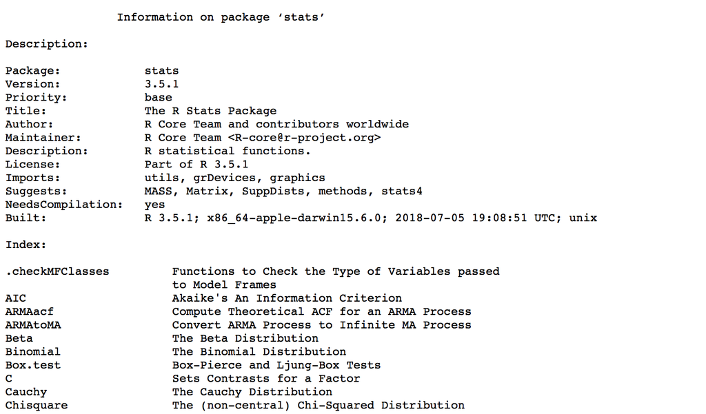

If the package has a vignette, we can check it through

[figure not shown]

```r
vignette("actuar")
```

I want to know the usage of a function.

```r
help.start() # Launches a web browser with search capability

help(function_name) # Get help on "function_name"

?function_name # Equivalent to the above

args(function_name) # See what arguments the function accepts

example(function_name) # See an example of the function

> example(mean)
mean> x <- c(0:10, 50)
mean> xm <- mean(x)
mean> c(xm, mean(x, trim = 0.10))
[1] 8.75 5.50
```

### Get external helps.

There are many supportive platforms on google that can give you helps.

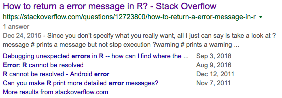

## 4. Read data

### Read data from a local directory

Common functions to read data from a file. This file could be .csv, .txt, .xlsx, etc.

```r
read.table(file, header = FALSE, sep = "", quote = "\"'",
           dec = ".", numerals = c("allow.loss", "warn.loss", "no.loss"),
           row.names, col.names, as.is = !stringsAsFactors,
           na.strings = "NA", colClasses = NA, nrows = -1,
           skip = 0, check.names = TRUE, fill = !blank.lines.skip,
           strip.white = FALSE, blank.lines.skip = TRUE,
           comment.char = "#",
           allowEscapes = FALSE, flush = FALSE,
           stringsAsFactors = default.stringsAsFactors(),
           fileEncoding = "", encoding = "unknown", text, skipNul = FALSE)
read.csv(file, header = TRUE, sep = ",", quote = "\"",
         dec = ".", fill = TRUE, comment.char = "", …)

read.csv2(file, header = TRUE, sep = ";", quote = "\"",
          dec = ",", fill = TRUE, comment.char = "", …)

read.delim(file, header = TRUE, sep = "\t", quote = "\"",
           dec = ".", fill = TRUE, comment.char = "", …)

read.delim2(file, header = TRUE, sep = "\t", quote = "\"",
            dec = ",", fill = TRUE, comment.char = "", …)
```

Examples:

```r
file_dir <- "/Users/Ziyi/Dropbox/BIOS545_2019/supp/mtcars.csv"
input <- read.table(file = file_dir, sep=",", header = T)
head(input)
```

|  | model | mpg | cyl | disp | hp | drat | wt | qsec | vs | am | gear | carb |
| --- | --- | --- | --- | --- | --- | --- | --- | --- | --- | --- | --- | --- |
| 1 | Mazda RX4 | 21.0 | 6 | 160 | 110 | 3.90 | 2.620 | 16.46 | 0 | 1 | 4 | 4 |
| 2 | Mazda RX4 Wag | 21.0 | 6 | 160 | 110 | 3.90 | 2.875 | 17.02 | 0 | 1 | 4 | 4 |
| 3 | Datsun 710 | 22.8 | 4 | 108 | 93 | 3.85 | 2.320 | 18.61 | 1 | 1 | 4 | 1 |
| 4 | Hornet 4 Drive | 21.4 | 6 | 258 | 110 | 3.08 | 3.215 | 19.44 | 1 | 0 | 3 | 1 |
| 5 | Hornet Sportabout | 18.7 | 8 | 360 | 175 | 3.15 | 3.440 | 17.02 | 0 | 0 | 3 | 2 |
| 6 | Valiant | 18.1 | 6 | 225 | 105 | 2.76 | 3.460 | 20.22 | 1 | 0 | 3 | 1 |

```r
file_dir <- "/Users/Ziyi/Dropbox/BIOS545_2019/supp/mtcars.csv"
input <- read.csv(file = file_dir, header = T)
head(input)
```

|  | model | mpg | cyl | disp | hp | drat | wt | qsec | vs | am | gear | carb |
| --- | --- | --- | --- | --- | --- | --- | --- | --- | --- | --- | --- | --- |
| 1 | Mazda RX4 | 21.0 | 6 | 160 | 110 | 3.90 | 2.620 | 16.46 | 0 | 1 | 4 | 4 |
| 2 | Mazda RX4 Wag | 21.0 | 6 | 160 | 110 | 3.90 | 2.875 | 17.02 | 0 | 1 | 4 | 4 |
| 3 | Datsun 710 | 22.8 | 4 | 108 | 93 | 3.85 | 2.320 | 18.61 | 1 | 1 | 4 | 1 |
| 4 | Hornet 4 Drive | 21.4 | 6 | 258 | 110 | 3.08 | 3.215 | 19.44 | 1 | 0 | 3 | 1 |
| 5 | Hornet Sportabout | 18.7 | 8 | 360 | 175 | 3.15 | 3.440 | 17.02 | 0 | 0 | 3 | 2 |
| 6 | Valiant | 18.1 | 6 | 225 | 105 | 2.76 | 3.460 | 20.22 | 1 | 0 | 3 | 1 |

This does the same thing as the above chunk.

```r
setwd("/Users/Ziyi/Dropbox/BIOS545_2019/supp")  # set working directory
input <- read.table(file = "mtcars.csv", sep=",", header = T)
```

### Read data from the Internet

You can read CSV fles directly from the Internet as long as you have the URL.

```r
url <- "https://www.dropbox.com/s/bgmvi7vbbqaq2ef/mtcars.csv?dl=1"
my.input <- read.table(url, header=T, sep=",")
head(my.input)
```

|  | model | mpg | cyl | disp | hp | drat | wt | qsec | vs | am | gear | carb |
| --- | --- | --- | --- | --- | --- | --- | --- | --- | --- | --- | --- | --- |
| 1 | Mazda RX4 | 21.0 | 6 | 160 | 110 | 3.90 | 2.620 | 16.46 | 0 | 1 | 4 | 4 |
| 2 | Mazda RX4 Wag | 21.0 | 6 | 160 | 110 | 3.90 | 2.875 | 17.02 | 0 | 1 | 4 | 4 |
| 3 | Datsun 710 | 22.8 | 4 | 108 | 93 | 3.85 | 2.320 | 18.61 | 1 | 1 | 4 | 1 |
| 4 | Hornet 4 Drive | 21.4 | 6 | 258 | 110 | 3.08 | 3.215 | 19.44 | 1 | 0 | 3 | 1 |
| 5 | Hornet Sportabout | 18.7 | 8 | 360 | 175 | 3.15 | 3.440 | 17.02 | 0 | 0 | 3 | 2 |
| 6 | Valiant | 18.1 | 6 | 225 | 105 | 2.76 | 3.460 | 20.22 | 1 | 0 | 3 | 1 |

You can also read tabular data from a webpage.

```r
read_html(file, skip = 0, remove.empty = TRUE, trim = TRUE, ...)
```

For example, you can read data from a Wikipedia page like the Wikipedia page for the World Population. https://en.wikipedia.org/wiki/List_of_countries_and_dependencies_by_population.

[figure not shown]

```r
library(rvest) # a package for easy web scraping with R
url <- "https://en.wikipedia.org/wiki/List_of_countries_and_dependencies_by_population" # url of the webpage
my_html <- read_html(url)
my_tables <- html_nodes(my_html,"table")[[1]]
populous_table <- html_table(my_tables)
populous_table <- populous_table[,-4:-6]
populous_table$Population <- as.numeric(gsub("," , "" , populous_table$Population)) / 100000
names(populous_table) <- c("Rank", "Country" , "Population")
head(populous_table)
```

|  | Rank | Country | Population |
| --- | --- | --- | --- |
| 1 | 1 | China[Note 2] | 13941.900 |
| 2 | 2 | India[Note 3] | 13421.000 |
| 3 | 3 | United States[Note 4] | 3285.130 |
| 4 | 4 | Indonesia | 2650.153 |
| 5 | 5 | Brazil | 2101.070 |
| 6 | 6 | Pakistan | 2033.240 |

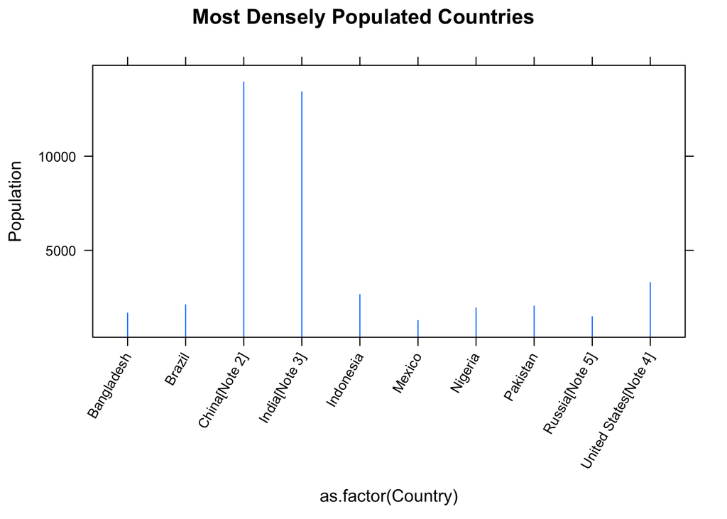

```r
# Let's plot the first 10 rows
library(lattice)
xyplot(Population ~ as.factor(Country), populous_table[1:10,],
scales = list(x = c(rot=60)),type="h",main="Most Densely Populated Countries")
```